# Week 2: Removing ambient RNA with SoupX (the manual route)

Kevin Z. Lin

2026-08-03

# 1 Overview

This overview was made from https://rawcdn.githack.com/constantAmateur/SoupX/204b602418df12e9fdb4b68775a8b486c6504fe4/inst/doc/pbmcTutorial.html.

This is the second SoupX tutorial. The first one ran the whole procedure on autopilot: `load10X()` assembled everything, `autoEstCont()` produced a contamination fraction, `adjustCounts()` cleaned the counts, and we trusted all three. This document takes the same three steps apart and does the middle one by hand.

There are two reasons to care, and both of them will apply to people in this room.

**First, the autopilot depends on things your data may not have.** Everything convenient in the first tutorial came from CellRanger’s `analysis/` folder being present and from `load10X()` finding it. If your experiment was not processed with CellRanger — a Parse run, a plate-based protocol, or a count matrix a collaborator emailed you — there is no `analysis/` folder, `load10X()` does not apply, and `autoEstCont()` refuses to run without clusters. You need to know how to assemble the object and attach the clustering yourself.

**Second, the automatic estimate can be wrong, and you should be able to check it.** In the first tutorial the estimate came back at `rho = 0.01`, sitting exactly on the floor of the estimator’s own search range. That was a defensible answer for a very clean dataset, but “the number landed on the boundary” is precisely the situation where you want a second, independent estimate. The manual route provides one.

The plan:

| Stage | What we do by hand | Functions |
| --- | --- | --- |
| Build the object | Read the two matrices ourselves instead of letting `load10X()` do it | `Read10X`, `SoupChannel`, `estimateSoup` |
| Attach the metadata | Read CellRanger’s clusters and tSNE from CSV and set them explicitly | `setClusters`, `setDR` |
| Choose estimation genes | Decide which genes are safe to measure contamination with | `quickMarkers`, `plotMarkerDistribution` |
| Choose estimation cells | Decide which cells can be assumed not to express them | `estimateNonExpressingCells` |
| Estimate and correct | Compute `rho` from those choices, then clean | `calculateContaminationFraction`, `adjustCounts` |

This assumes you have been through the first tutorial. Concepts introduced there — the soup, `rho`, the soup profile, why the correction is done cluster-wise — are not re-explained here.

# 2 Setting up

```r
library(SoupX)
library(Matrix)
library(ggplot2)
```

```r
rm(list = ls())
```

# 3 Getting the data

We use the 10x **PBMC 4k** dataset: about 4,300 peripheral blood mononuclear cells from a healthy donor, processed with an older version of CellRanger.

We download three archives. Two are the count matrices; the third is CellRanger’s secondary analysis, which we will deliberately read by hand later.

```r
tmp_dir <- tempdir(check = TRUE)
base_url <- "https://cf.10xgenomics.com/samples/cell-exp/2.1.0/pbmc4k/pbmc4k"

for (component in c("raw_gene_bc_matrices",
                    "filtered_gene_bc_matrices",
                    "analysis")) {
  destination <- file.path(tmp_dir, paste0(component, ".tar.gz"))
  download.file(paste0(base_url, "_", component, ".tar.gz"),
                destfile = destination)
  untar(destination, exdir = tmp_dir)
}
```

Note the folder names: `raw_gene_bc_matrices` and `filtered_gene_bc_matrices`, not `raw_feature_bc_matrix` and `filtered_feature_bc_matrix` as in the first tutorial. This dataset was produced by CellRanger 2.1, before 10x renamed these outputs. Underneath each is a further folder named after the reference genome, `GRCh38`. Small differences like this are the normal texture of working with other people’s data, and they are why hardcoding paths from a tutorial into your own analysis tends to fail.

# 4 Building the SoupChannel by hand

In the first tutorial a single call to `load10X()` did everything. Here we do it in pieces, because seeing the pieces is the point.

`Read10X()` turns a folder of 10x files into a sparse count matrix. We call it twice: once for the droplets that CellRanger called as cells (the **t**able **o**f **c**ounts, `toc`), and once for every droplet including the empty ones (the **t**able **o**f **d**roplets, `tod`).

```r
toc <- Seurat::Read10X(file.path(tmp_dir, "filtered_gene_bc_matrices", "GRCh38"))
tod <- Seurat::Read10X(file.path(tmp_dir, "raw_gene_bc_matrices", "GRCh38"))

dim(toc)
```

```
## [1] 33694  4340
```

```r
dim(tod)
```

```
## [1]  33694 737280
```

The two matrices have the same 33,694 genes but wildly different numbers of columns: 4,340 cells in `toc` against **737,280** droplets in `tod`. That second number is the full 10x barcode whitelist — every barcode the chemistry could possibly have produced — so more than 99% of those droplets contain no cell at all. That enormous empty majority is exactly what makes the soup measurable.

Now we assemble the object. `calcSoupProfile = FALSE` tells `SoupChannel()` not to profile the soup on construction, and then we do it in a separate, visible step. The two-step version is equivalent to the default, but it makes it obvious that profiling the soup is a real computation and not something that comes free with the object.

```r
sc <- SoupX::SoupChannel(tod, toc, calcSoupProfile = FALSE)
sc <- SoupX::estimateSoup(sc)
sc
```

`estimateSoup()` looks at droplets with fewer than 100 UMIs — its default `soupRange = c(0, 100)` — and computes each gene’s share of the counts in them. That is step 1 of the method, now done explicitly.

```r
head(sc$soupProfile[order(sc$soupProfile$est, decreasing = TRUE), ], n = 20)
```

```
##                est counts
## MALAT1 0.032491616  88000
## B2M    0.019416325  52587
## TMSB4X 0.016583278  44914
## EEF1A1 0.012944217  35058
## RPL21  0.010354856  28045
## RPS27  0.010097877  27349
## RPL13  0.009351309  25327
## RPL13A 0.008643877  23411
## RPL10  0.008105920  21954
## RPLP1  0.007909124  21421
## RPL34  0.007891401  21373
## RPS12  0.007672083  20779
## RPS18  0.007560208  20476
## RPS3A  0.007439842  20150
## RPL32  0.007433934  20134
## RPS6   0.007406612  20060
## RPS27A 0.007243415  19618
## RPS2   0.007188770  19470
## RPL41  0.006997143  18951
## RPL11  0.006277897  17003
```

`MALAT1` tops the list at about 3.3%, followed by `B2M`, `TMSB4X`, `EEF1A1` and then a long run of ribosomal protein genes. The `counts` column shows how much evidence sits behind each estimate — 88,000 `MALAT1` counts pooled across the empty droplets, so these are not fragile numbers.

# 5 Attaching clusters and dimension reduction after the fact

This section is the heart of the tutorial.

At this moment `sc` has counts and a soup profile, and **nothing else**. It has no clusters, so `autoEstCont()` would fail on it and `adjustCounts()` would fall back to a weaker cell-by-cell correction. We downloaded CellRanger’s `analysis/` folder, but we never pointed `load10X()` at it, so nothing was picked up automatically. That is deliberate: we are going to attach the information ourselves, exactly as you would if it had come from a Seurat run, a collaborator, or any other outside source.

CellRanger writes its clustering as a two-column CSV.

```r
clustering_df <- read.csv(file.path(tmp_dir, "analysis", "clustering",
                                    "graphclust", "clusters.csv"))
head(clustering_df)
```

```
##              Barcode Cluster
## 1 AAACCTGAGAAGGCCT-1       2
## 2 AAACCTGAGACAGACC-1       2
## 3 AAACCTGAGATAGTCA-1       2
## 4 AAACCTGAGCGCCTCA-1       8
## 5 AAACCTGAGGCATGGT-1       3
## 6 AAACCTGCAAGGTTCT-1       1
```

```r
table(clustering_df$Cluster)
```

```
##
##    1    2    3    4    5    6    7    8
## 1294  708  611  462  453  376  297  139
```

`setClusters()` wants a vector of cluster labels **named by cell barcode**, not a data frame. `setNames()` builds exactly that: it takes the values as its first argument and the names as its second.

```r
sc <- SoupX::setClusters(sc, setNames(clustering_df$Cluster,
                                      clustering_df$Barcode))
```

> **The mistake to avoid.** It is tempting to write `setNames(clustering_df$Cluster, rownames(clustering_df))`. After `read.csv()`, the row names of a data frame are just `"1"`, `"2"`, `"3"`, … — the barcodes live in the `Barcode` *column*, not in the row names. With row names, the labels have no barcode to match against; SoupX falls back to assigning them **by position**, which silently gives the right answer only if the CSV happens to be in the same order as the count matrix. It is here, but relying on that is how you get a plot that looks fine and is wrong. Name things by barcode and let the matching be explicit.

The same idea for the tSNE coordinates.

```r
tsne_df <- read.csv(file.path(tmp_dir, "analysis", "tsne",
                              "2_components", "projection.csv"))
head(tsne_df)
```

```
##              Barcode    TSNE.1     TSNE.2
## 1 AAACCTGAGAAGGCCT-1 -12.91483  -6.727199
## 2 AAACCTGAGACAGACC-1 -16.52803  -7.060293
## 3 AAACCTGAGATAGTCA-1 -14.93287 -19.343775
## 4 AAACCTGAGCGCCTCA-1  15.91147  -9.198154
## 5 AAACCTGAGGCATGGT-1  25.58012   7.792741
## 6 AAACCTGCAAGGTTCT-1  14.49733  -4.899850
```

Two small things to handle. The CSV’s columns are named `TSNE-1` and `TSNE-2`, but `read.csv()` converts hyphens to dots, so in R they arrive as `TSNE.1` and `TSNE.2` — a good habit is to always `head()` a freshly read file rather than assume its column names. And `setDR()` matches on row names, so we move the barcodes there.

```r
rownames(tsne_df) <- tsne_df$Barcode
sc <- SoupX::setDR(sc, tsne_df[colnames(sc$toc), c("TSNE.1", "TSNE.2")])

head(sc$metaData)
```

```
##                    nUMIs clusters    TSNE.1     TSNE.2
## AAACCTGAGAAGGCCT-1  1738        2 -12.91483  -6.727199
## AAACCTGAGACAGACC-1  3240        2 -16.52803  -7.060293
## AAACCTGAGATAGTCA-1  1683        2 -14.93287 -19.343775
## AAACCTGAGCGCCTCA-1  2319        8  15.91147  -9.198154
## AAACCTGAGGCATGGT-1  2983        3  25.58012   7.792741
## AAACCTGCAAGGTTCT-1  4181        1  14.49733  -4.899850
```

Indexing with `tsne_df[colnames(sc$toc), ]` reorders the rows to match the count matrix’s columns. Even when the file is already in the right order — as it is here — writing it this way means the code stays correct if it ever is not.

# 6 A first look at the data

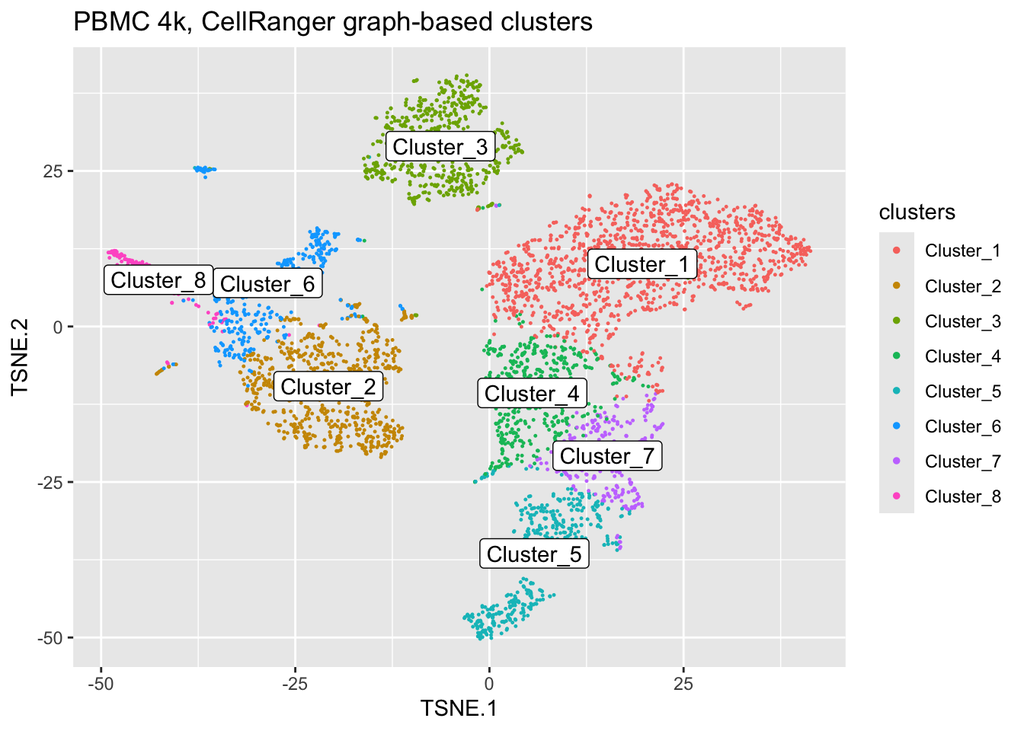

```r
dd <- sc$metaData[colnames(sc$toc), ]
dd$clusters <- as.factor(paste0("Cluster_", dd$clusters))

mids <- aggregate(cbind(TSNE.1, TSNE.2) ~ clusters, data = dd, FUN = mean)

gg <- ggplot2::ggplot(dd, ggplot2::aes(TSNE.1, TSNE.2)) +
  ggplot2::geom_point(ggplot2::aes(colour = clusters), size = 0.2) +
  ggplot2::geom_label(data = mids, ggplot2::aes(label = clusters)) +
  ggplot2::ggtitle("PBMC 4k, CellRanger graph-based clusters") +
  ggplot2::guides(colour = ggplot2::guide_legend(override.aes = list(size = 1)))
plot(gg)
```

Note that the coordinate columns are still called `TSNE.1` and `TSNE.2` here. `setDR()` does not rename what you hand it — it copies your columns into `sc$metaData` under their existing names and records which ones they are in `sc$DR`. (The SoupX vignette calls them `RD1` and `RD2` only because its bundled metadata happened to arrive with those names.) The plotting functions later in this document read `sc$DR`, so they will find these coordinates whatever they are called.

Note also that these clusters are **numbered, not named**. CellRanger does not know what a B cell is. Deciding which cluster is which cell type is Week 4’s topic; for now the numbers are enough, because the contamination estimate needs to know only which cells group together, not what they are.

# 7 Choosing genes to estimate the contamination with

Here is the whole idea in one sentence: **if we can find a gene that a cell definitely does not express, then every count of that gene in that cell must have come from the soup**, and comparing that count to the soup profile gives us `rho` for that cell.

So we need genes that are confidently *off* in some identifiable set of cells. The difficulty is entirely in the word “confidently.”

## 7.1 Why the most abundant soup genes are the wrong choice

The obvious move is to use whatever is most abundant in the soup, since those give the strongest signal. Look again at the top of the soup profile above: `MALAT1`, `B2M`, `TMSB4X`, `EEF1A1`, and a dozen ribosomal protein genes. Those are the worst possible choices, because every cell expresses them. There is no set of cells for which we can say the true expression is zero, so any “contamination” we measure in them is mostly real biology.

`RPL10` makes the point concretely: it sits ninth in the soup profile, at 0.81% of all background counts. Abundant — and useless for our purpose, because it is abundant *everywhere*. A marker map for it looks busy, but that signal is genuine ribosomal expression in every cluster, not contamination.

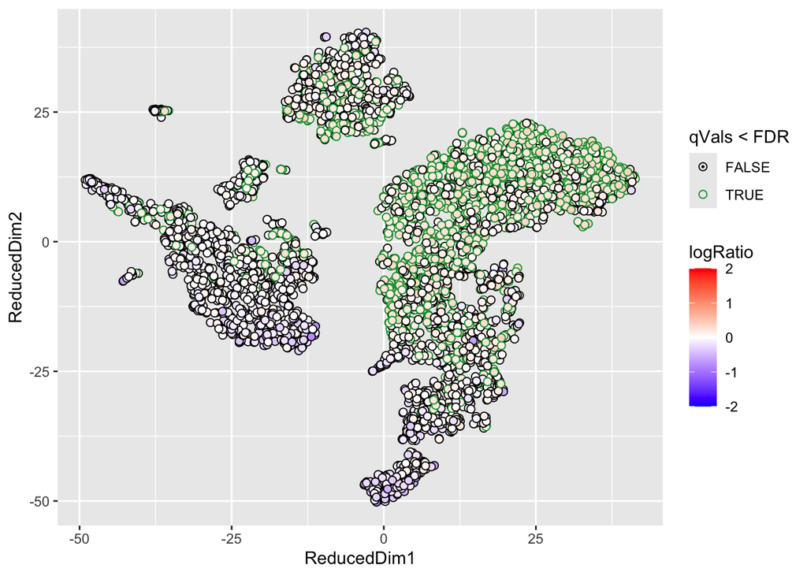

```r
gg <- SoupX::plotMarkerMap(sc, "RPL10")
plot(gg)
```

The useful genes are the opposite kind: **highly expressed in one cell type and genuinely absent everywhere else**. `LYZ`, the monocyte marker from the first tutorial, is that sort of gene. So is `IGKC`, an antibody gene made only by B cells, and so is haemoglobin (`HBB`, `HBA2`) in tissue where red cells are the only source.

## 7.2 Letting the data suggest candidates

`plotMarkerDistribution()` gives a survey. For each candidate gene it shows the distribution across cells of the ratio of observed counts to what pure soup would produce, with a red line marking the contamination fraction you would infer from that gene alone.

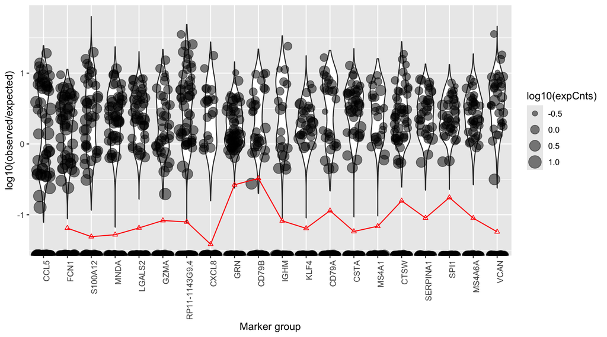

```r
SoupX::plotMarkerDistribution(sc)
```

> **Read this plot, do not automate it.** The SoupX authors are emphatic on this point: it is a heuristic to develop your intuition, and if you simply take the top N genes from it and estimate contamination with them, **you will over-estimate**. That is why the function returns a plot and not a gene list.

For a systematic candidate set we use `quickMarkers()`, which finds the genes most specific to each cluster. Specificity is scored by tf-idf, the same measure used to find words that characterize a document.

```r
marker_genes <- SoupX::quickMarkers(sc$toc, sc$metaData$clusters)
head(marker_genes[, c("gene", "cluster", "tfidf", "qval")])
```

```
##      gene cluster     tfidf          qval
## 1    LEF1       1 0.8152309 9.243781e-234
## 2    CCR7       1 0.7745260 4.883133e-190
## 3     MAL       1 0.7045845 1.357874e-129
## 4 LDLRAP1       1 0.7016545 2.249239e-128
## 5  FLT3LG       1 0.6492362  1.106698e-94
## 6 PIK3IP1       1 0.6490943 5.960332e-107
```

The top hits for cluster 1 — `LEF1`, `CCR7`, `MAL`, `FLT3LG` — are naive T-cell genes, with q-values that leave no doubt. `quickMarkers()` has found real biology without being told any, which is the whole reason it is usable on a dataset you have never seen.

We reshape the result into a list: one entry per cluster, containing that cluster’s marker genes.

```r
cluster_genes <- split(marker_genes$gene, marker_genes$cluster)
lengths(cluster_genes)
```

```
##  1  2  3  4  5  6  7  8
## 10 10 10 10 10 10 10 10
```

Ten genes per cluster, because `quickMarkers()` defaults to `N = 10` — it returns the top ten markers per cluster, not every gene that passes significance. Raising `N` gives more genes to estimate from but admits progressively less specific ones, which is a trade-off rather than a free improvement.

Note that we split on `marker_genes$gene`, the **column** holding the gene names. `quickMarkers()` leaves the row names as `"1"`, `"2"`, `"3"`, … — the same trap as with the clusters CSV above, and it bites the same way: `split()` on row names returns lists of row numbers, and SoupX would then look for genes literally named `"1"` and find nothing.

The reason `nonExpressedGeneList` is a *list* of gene sets rather than one flat vector is that genes are grouped by biology. Immunoglobulin genes rise and fall together; haemoglobin genes rise and fall together. SoupX uses or excludes each group as a unit.

# 8 Choosing which cells to estimate from

Having picked gene sets, we now need, for each set, the cells that can be assumed not to express it. A B-cell marker tells us nothing about contamination *in B cells* — there the expression is real.

```r
useToEst <- SoupX::estimateNonExpressingCells(sc, nonExpressedGeneList = cluster_genes)
dim(useToEst)
```

```
## [1] 4340    8
```

The result is 4,340 × 8 — one row per cell, one column per gene set — holding TRUE/FALSE: may this cell be used to estimate contamination with this gene set?

SoupX is deliberately conservative here. Because we supplied clusters, it works at cluster level: if *any* cell in a cluster shows convincing evidence of expressing a gene set, the entire cluster is excluded for that set. Excluding real expressers matters much more than losing some cells, since a cell that genuinely expresses the gene would inflate `rho` and cause over-correction.

We can look at the decision for a couple of gene sets. Cells outlined in green are the ones being used for estimation; the fill colour is the observed-to-soup ratio.

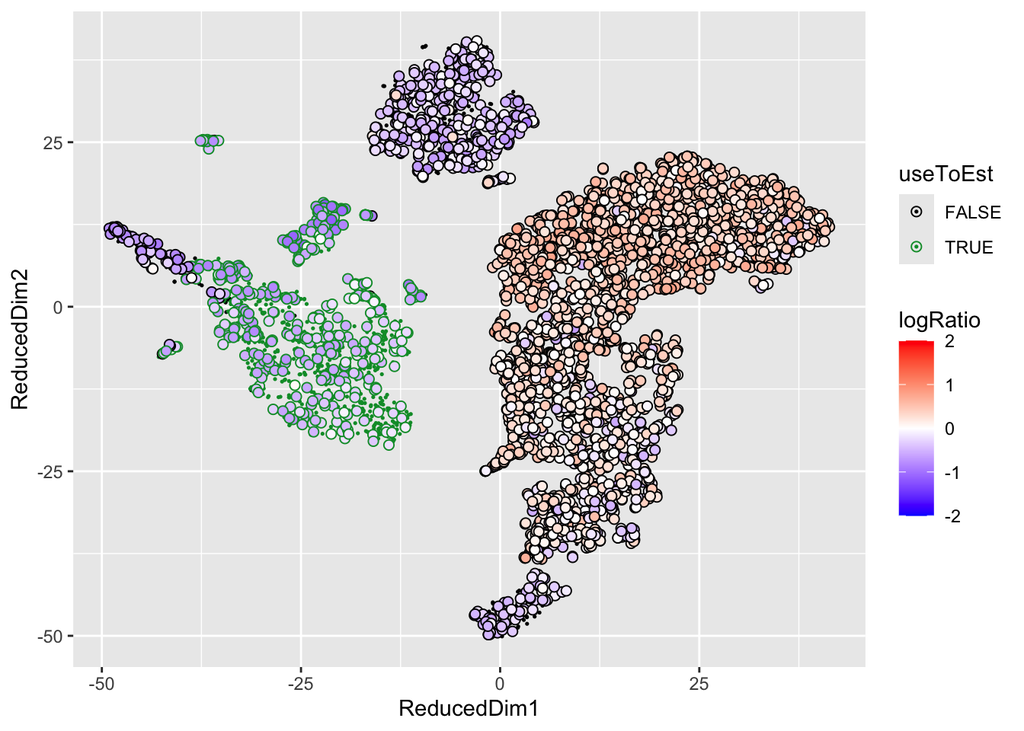

```r
SoupX::plotMarkerMap(sc, geneSet = cluster_genes[[1]], useToEst = useToEst[, 1])
```

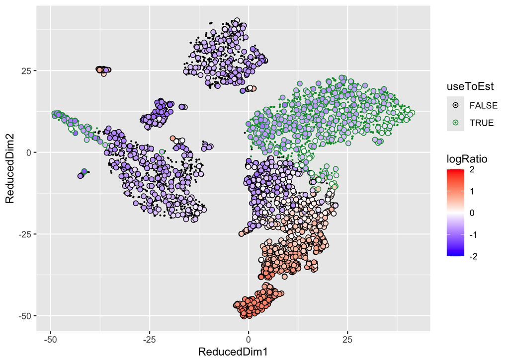

```r
SoupX::plotMarkerMap(sc, geneSet = cluster_genes[[5]], useToEst = useToEst[, 5])
```

# 9 Calculating the contamination fraction

All the judgement has now been made. The arithmetic is one call.

```r
sc <- SoupX::calculateContaminationFraction(sc, cluster_genes, useToEst = useToEst)
```

```
## Estimated global contamination fraction of 9.78%
```

```r
head(sc$metaData)
```

```
##                    nUMIs clusters    TSNE.1     TSNE.2        rho     rhoLow
## AAACCTGAGAAGGCCT-1  1738        2 -12.91483  -6.727199 0.09780985 0.09525635
## AAACCTGAGACAGACC-1  3240        2 -16.52803  -7.060293 0.09780985 0.09525635
## AAACCTGAGATAGTCA-1  1683        2 -14.93287 -19.343775 0.09780985 0.09525635
## AAACCTGAGCGCCTCA-1  2319        8  15.91147  -9.198154 0.09780985 0.09525635
## AAACCTGAGGCATGGT-1  2983        3  25.58012   7.792741 0.09780985 0.09525635
## AAACCTGCAAGGTTCT-1  4181        1  14.49733  -4.899850 0.09780985 0.09525635
##                      rhoHigh
## AAACCTGAGAAGGCCT-1 0.1004085
## AAACCTGAGACAGACC-1 0.1004085
## AAACCTGAGATAGTCA-1 0.1004085
## AAACCTGAGCGCCTCA-1 0.1004085
## AAACCTGAGGCATGGT-1 0.1004085
## AAACCTGCAAGGTTCT-1 0.1004085
```

**9.78%** — nearly ten times the `rho = 0.01` of the first tutorial. Roughly one count in ten in this dataset came from the soup rather than from the cell it was assigned to. Now the correction has something substantial to do.

Unlike `autoEstCont()`, this function also records `rhoLow` and `rhoHigh`, a confidence interval on the estimate. Here it runs from 0.0953 to 0.1004 — a spread of half a percentage point, which is tight. That tells us the gene sets carried plenty of information and the estimate is well determined. A wide interval, or one running down towards 0, would be a signal to revisit the gene and cell choices above rather than to accept the number.

> **A number that does not match the vignette, and why.** The SoupX vignette gets 7.69% on this same dataset; we get 9.78%. The difference is the gene sets. The vignette estimates from immunoglobulin genes only — a set its authors were confident about on biological grounds — whereas we used the top markers of all eight clusters. More gene sets means more cells contributing, but also admits genes whose “non-expression” is less certain, which pushes the estimate up. Neither number is the true value; both are estimates from different, defensible choices. This is worth sitting with, because it is the honest situation you are in with your own data: the contamination fraction is not read off the data, it is *inferred from assumptions you make*, and reasonable assumptions differ by a couple of percentage points. Recall from the first tutorial that SoupX is forgiving of exactly this kind of error.

## 9.1 How this compares to the automatic route

It is worth being clear about what actually differed. `autoEstCont()` performs these same steps: it calls `quickMarkers()`, applies `estimateNonExpressingCells()`, and computes `rho` from many gene–cluster pairs. The differences are that it filters the marker list more aggressively (by tf-idf and by abundance in the soup), it combines the many per-gene estimates by taking the mode of their posterior rather than a single pooled calculation, and it constrains the answer to `contaminationRange`.

So this is not a different method so much as the same method with the decisions exposed. The value of doing it by hand is that you can substitute your own biology at the point where it matters. If you know your tissue contains red blood cells, `list(HB = c("HBB", "HBA2"))` is a better gene set than anything `quickMarkers()` will find for you.

# 10 Correcting the counts

```r
out <- SoupX::adjustCounts(sc)
```

# 11 What actually changed

As before, the fraction of expressing cells driven to zero for each gene:

```r
cnt_soggy <- Matrix::rowSums(sc$toc > 0)
cnt_strained <- Matrix::rowSums(out > 0)
most_zeroed <- tail(sort((cnt_soggy - cnt_strained) / cnt_soggy), n = 10)
most_zeroed
```

```
##     IGLC3      PPBP      NKG7      CST3      GNLY      IGKC       LYZ    S100A8
## 0.4610092 0.4800000 0.4926045 0.4927235 0.5557809 0.5745951 0.5771860 0.6020217
##     IGLC2    S100A9
## 0.6116505 0.6254582
```

Compare with the first tutorial, where the largest value was 0.14. Here the list runs from 0.46 to **0.63**: for `S100A9`, 63% of the cells that had a non-zero count now have none. Nearly ten times the soup produced a categorically different correction, not merely a larger one.

The genes themselves are the story. Every one is a high-expression marker of a single population:

- `S100A9`, `S100A8`, `LYZ`, `CST3` — monocytes and myeloid cells.
- `IGLC2`, `IGKC`, `IGLC3` — immunoglobulin, made only by B cells.
- `GNLY`, `NKG7` — cytotoxic granule genes from NK and effector T cells.
- `PPBP` — platelets.

This is the same pattern as the first tutorial, where the equivalent list was led by platelet and myeloid genes, but far more pronounced. Note that `LYZ` (0.577) and `IGKC` (0.575) — the two genes we look at directly below — are themselves in this top ten, out of all 33,694 genes. They are not incidental examples; they are among the genes the correction touches most.

And the genes that changed quantitatively:

```r
tail(sort(Matrix::rowSums(sc$toc > out) / Matrix::rowSums(sc$toc > 0)), n = 20)
```

```
##      S100B      PRMT2     MT-ND1     MT-ND2     MT-CO1     MT-CO2    MT-ATP8
##          1          1          1          1          1          1          1
##    MT-ATP6     MT-CO3     MT-ND3    MT-ND4L     MT-ND4     MT-ND5     MT-ND6
##          1          1          1          1          1          1          1
##     MT-CYB BX004987.4 AC011043.1 AL592183.1 AC007325.4 AC004556.1
##          1          1          1          1          1          1
```

The mitochondrial genes dominate, as they did in the first tutorial: `MT-ND1` through `MT-CYB`, every one at a ratio of 1, meaning every cell expressing them lost counts. Mitochondrial transcripts are over-represented in the background relative to cells, so this is the expected result and it carries the same warning as before — **ambient RNA inflates the mitochondrial fraction you filter on during quality control**, so some cells that look low-quality are simply soupy.

The same caveat as the first tutorial also applies to the rest of the list. `BX004987.4`, `AC011043.1`, `AL592183.1` and the other accession-numbered loci are detected in very few cells, so the denominator of the ratio is tiny and reaching exactly 1.0 takes almost nothing. Check the denominator before reading meaning into the top of a sorted ratio.

## 11.1 The correction, seen directly

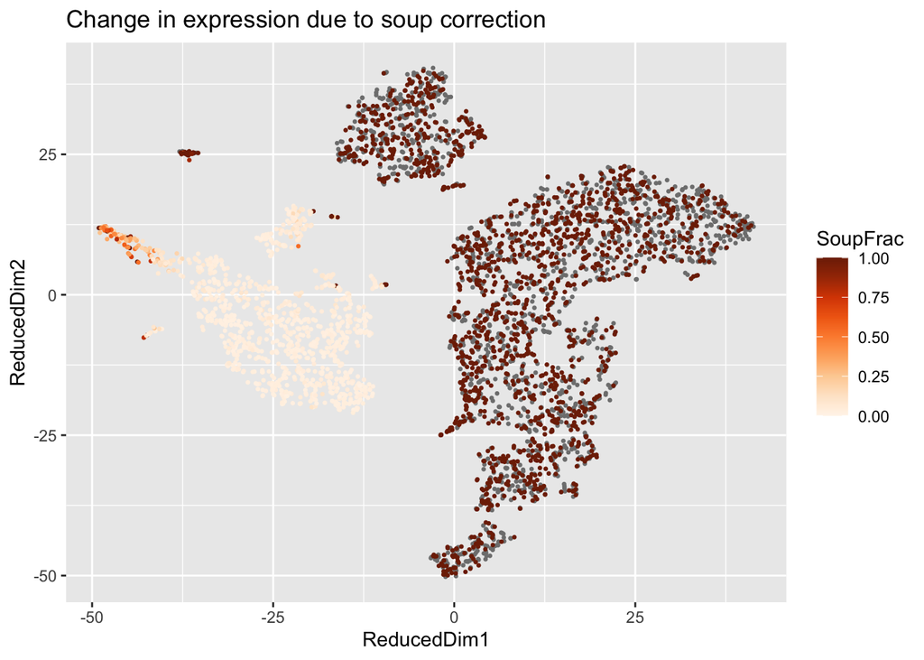

```r
SoupX::plotChangeMap(sc, out, "LYZ")
```

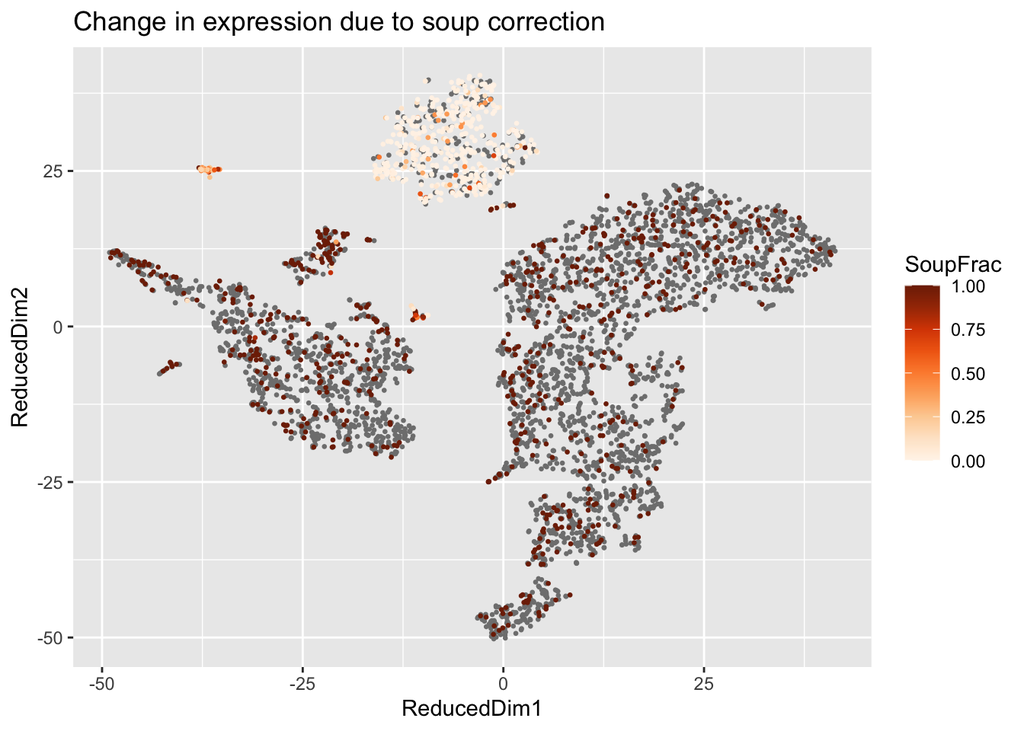

```r
SoupX::plotChangeMap(sc, out, "IGKC")
```

`LYZ` should lose its scatter outside the monocyte cluster and `IGKC` outside the B cells, while both keep their counts where the expression is real. We know from the table above that this is a large effect — each gene lost its counts entirely in about 57% of the cells that had any — so on this dirtier dataset the change should be far more visible than the near-invisible correction in the first tutorial.

Contrast that with a ubiquitously expressed gene:

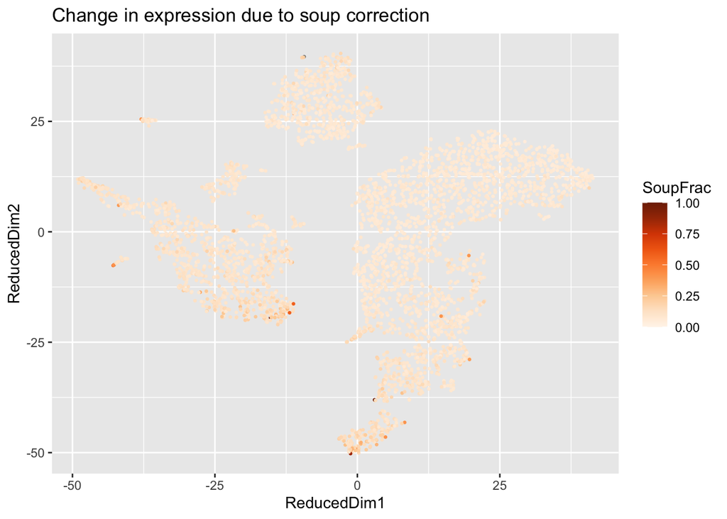

```r
SoupX::plotChangeMap(sc, out, "RPL10")
```

`RPL10` is abundant in the soup, so counts are removed from it too — but they are removed roughly evenly everywhere, because every cell genuinely expresses it. Nothing about the interpretation of `RPL10` changes. This is the visual version of the earlier point: correction reshapes the genes whose expression is concentrated in one cell type, and merely rescales the ones that are not.

# 12 Using the cleaned matrix downstream

```r
pbmc <- Seurat::CreateSeuratObject(counts = out)
```

# 13 What we glossed over

- **We still took CellRanger’s clusters as given.** We attached them by hand rather than having them attached for us, but we did not produce or evaluate them. Clustering is Week 3. The good news is that SoupX is not very sensitive to the clustering used — Seurat defaults give similar results — because the clusters only need to group cells well enough to tell which ones express a gene set.
- **The gene sets came from the data, not from biology.** We used `quickMarkers()` because it generalizes to a dataset you know nothing about. When you *do* know the biology, naming the genes yourself is better — and as the 9.78%-versus-7.69% discrepancy above shows, the choice moves the answer by a couple of percentage points. For a tissue with red cell contamination, for example: `list(HB = c("HBB", "HBA2"), IG = c("IGKC", "IGHG1", "IGHM"))`.
- **We never cross-checked with `autoEstCont()`.** This dataset has clusters attached now, so the automatic estimator would run on it. Comparing the two numbers costs one line and is a genuinely good habit.
- **We accepted the default FDR thresholds** in `estimateNonExpressingCells()`, which control how much evidence of expression is needed to exclude a cluster.
- **`rho` is still one number for the whole channel.** Both routes assume a constant contamination fraction across cells within a channel.
- **We did not verify that the correction helped.** The honest test is downstream: cluster the corrected and uncorrected matrices and see whether marker genes become more cell-type specific. That is a Week 3 exercise, and a good one.

# 14 References

- Young MD, Behjati S. *SoupX removes ambient RNA contamination from droplet-based single-cell RNA sequencing data.* GigaScience 9(12), 2020. [doi:10.1093/gigascience/giaa151](https://doi.org/10.1093/gigascience/giaa151)
- PBMC 4k dataset (10x Genomics, CellRanger 2.1.0). The files used above are downloaded directly from `https://cf.10xgenomics.com/samples/cell-exp/2.1.0/pbmc4k/`; the dataset’s documentation page is support.10xgenomics.com/single-cell-gene-expression/datasets/2.1.0/pbmc4k.